## Размерная структура

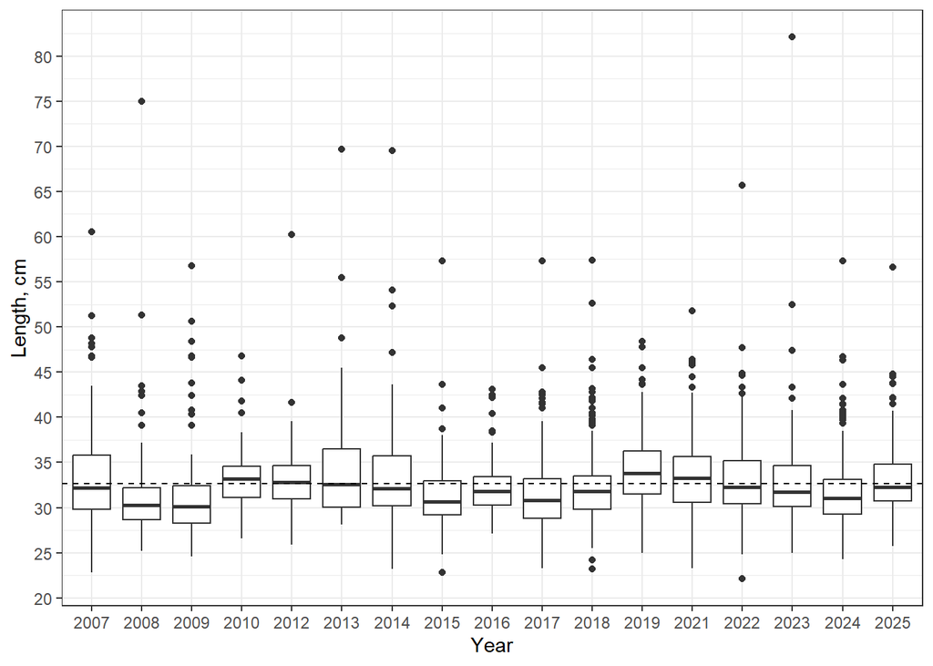

- Прислать абсолютные значения средних длин трески за разные годы (нужен размах колебаний). Какова среднемноголетняя величина размеров трески, приведенная на рисунке?

| Year | Mean_L | SD | Min | Max |
| --- | --- | --- | --- | --- |
| 2007 | 33.00240 | 5.335371 | 22.8 | 60.5 |
| 2008 | 32.10000 | 7.423668 | 25.2 | 75.0 |
| 2009 | 31.45657 | 5.623931 | 24.6 | 56.8 |
| 2010 | 33.56410 | 4.423293 | 26.6 | 46.8 |
| 2012 | 33.27255 | 5.064705 | 25.9 | 60.2 |
| 2013 | 34.40882 | 6.925590 | 28.1 | 69.7 |
| 2014 | 33.99437 | 7.067893 | 23.2 | 69.5 |
| 2015 | 31.44841 | 3.995752 | 22.8 | 57.3 |
| 2016 | 32.59231 | 3.658864 | 27.1 | 43.1 |
| 2017 | 31.35886 | 3.850801 | 23.3 | 57.3 |
| 2018 | 32.36722 | 4.248397 | 23.2 | 57.4 |
| 2019 | 34.57386 | 4.531968 | 25.0 | 48.4 |
| 2021 | 33.70781 | 4.748603 | 23.3 | 51.8 |
| 2022 | 33.76049 | 6.017198 | 22.1 | 65.7 |
| 2023 | 33.02602 | 6.226146 | 25.0 | 82.1 |
| 2024 | 31.85580 | 4.140033 | 24.3 | 57.3 |
| 2025 | 33.23522 | 4.056549 | 25.7 | 56.6 |

По всему материалу

| Mean_L | SD | Min | Max |
| --- | --- | --- | --- |
| 32.63439 | 5.012195 | 22.1 | 82.1 |

- На оси ординат (Length, cm) нанести более дробные значения длины (по 5 см), чтобы было понятно среднемноголетнее значение и размах колебаний по годам.

**Сделал**

- Разобраться с сезонной динамикой размерного состава выборок

Иного способа, кроме построения модели, где зависимой переменной будет длина, а предикторами год и DOY, не вижу. Проблема будет в том, что модель, конечно покажет значимую связь с годом.

Вот результаты подбора этой модели.

```
##
## Family: gaussian
## Link function: identity
##
## Formula:
## L ~ s(Year) + s(DOY)
##
## Parametric coefficients:
##             Estimate Std. Error t value Pr(>|t|)
## (Intercept)   32.634      0.106   307.9   <2e-16 ***
## ---
## Signif. codes:  0 '***' 0.001 '**' 0.01 '*' 0.05 '.' 0.1 ' ' 1
##
## Approximate significance of smooth terms:
##           edf Ref.df     F  p-value
## s(Year) 7.268  8.217 5.160 2.83e-06 ***
## s(DOY)  7.429  8.354 1.751    0.059 .
## ---
## Signif. codes:  0 '***' 0.001 '**' 0.01 '*' 0.05 '.' 0.1 ' ' 1
##
## R-sq.(adj) =  0.0286   Deviance explained = 3.52%
## GCV = 24.582  Scale est. = 24.404    n = 2172
```

Видно, что значимой связи с сезоном нет, но если этот вопрос поднимать, то придется объяснять что-то про динамику размера.

## Динамика полового состава

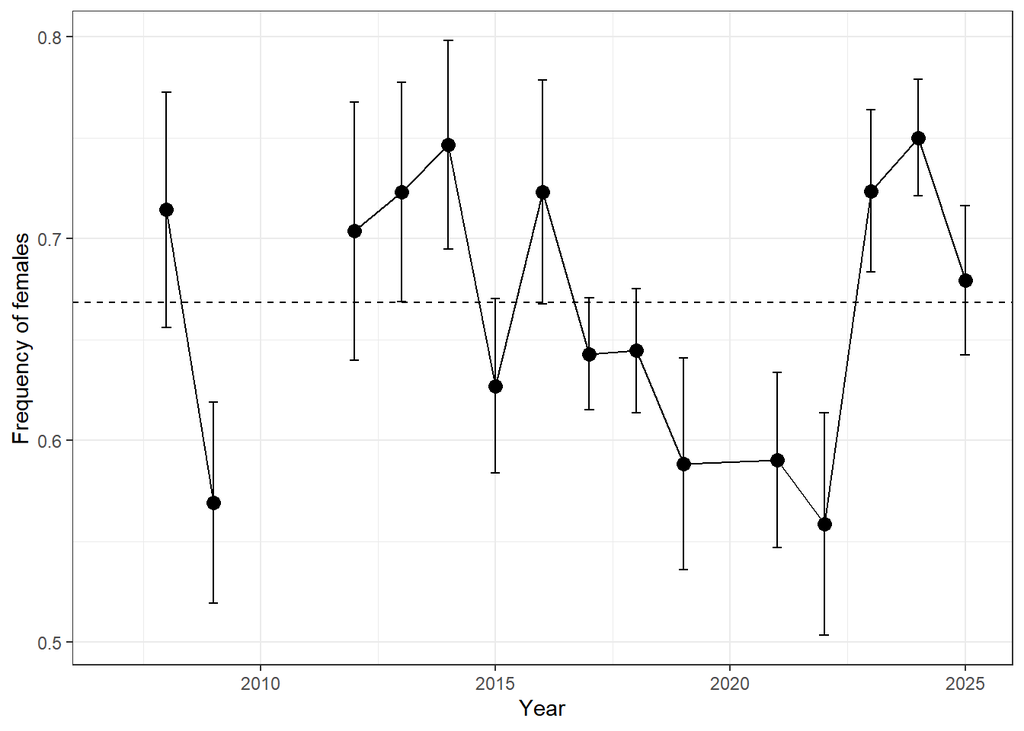

# Общее описание рациона

## Таблица с характеристиками питания

Средний вес в пищевом комке

| Species | 2007 | 2008 | 2009 | 2010 | 2012 | 2013 | 2014 | 2015 | 2016 | 2017 | 2018 | 2019 | 2021 | 2022 | 2023 | 2024 | 2025 |
| --- | --- | --- | --- | --- | --- | --- | --- | --- | --- | --- | --- | --- | --- | --- | --- | --- | --- |
| G.aculeatus | 2.21 | 2.15 | 1.82 | 1.77 | 2.94 | 2.81 | 2.45 | 2.50 | 3.60 | 1.91 | 1.85 | 3.03 | 1.80 | 2.07 | 2.51 | 2.09 | 1.53 |
| C.pallasii_marisalbi | 0.16 | 0.70 | 0.76 | 0.36 | 1.14 | 0.84 | 0.89 | 0.03 | 0.00 | 0.21 | 0.73 | 2.03 | 4.45 | 2.00 | 0.88 | 0.81 | 1.79 |
| P.gunnelus | 0.31 | 0.23 | 0.48 | 0.51 | 0.00 | 0.13 | 0.08 | 0.09 | 0.00 | 0.12 | 0.00 | 0.05 | 0.16 | 0.00 | 0.00 | 0.00 | 0.00 |
| M.scorpuis | 0.06 | 0.08 | 0.28 | 0.00 | 0.16 | 0.50 | 0.00 | 0.00 | 0.00 | 0.06 | 0.00 | 0.40 | 0.17 | 0.21 | 0.16 | 0.00 | 0.03 |
| G.morhua_marisalbi | 0.58 | 0.00 | 0.08 | 0.00 | 0.00 | 0.12 | 1.06 | 0.00 | 0.00 | 0.06 | 0.00 | 0.36 | 0.00 | 1.14 | 0.33 | 0.08 | 0.00 |
| A.marinus | 0.10 | 0.05 | 0.00 | 0.00 | 0.00 | 0.00 | 0.42 | 0.36 | 0.00 | 1.25 | 0.42 | 0.05 | 0.00 | 0.00 | 0.00 | 0.02 | 0.00 |
| C.lumpus | 0.01 | 0.00 | 0.00 | 0.00 | 0.00 | 0.00 | 0.00 | 0.00 | 0.00 | 0.00 | 0.00 | 0.00 | 0.00 | 0.00 | 0.00 | 0.00 | 0.00 |
| Fish_eggs | 0.30 | 0.77 | 0.62 | 0.10 | 0.35 | 0.56 | 0.82 | 2.47 | 1.09 | 0.96 | 1.17 | 0.70 | 0.88 | 0.11 | 1.20 | 1.43 | 0.38 |
| Lumpenus_sp. | 0.32 | 0.10 | 0.12 | 0.08 | 0.24 | 0.22 | 0.39 | 0.16 | 0.00 | 0.11 | 0.00 | 0.00 | 1.21 | 0.41 | 0.50 | 0.19 | 0.39 |
| L.limanda | 0.06 | 0.00 | 0.00 | 0.00 | 0.39 | 0.00 | 0.14 | 0.00 | 0.00 | 0.00 | 0.00 | 0.00 | 0.13 | 0.09 | 0.10 | 0.04 | 1.26 |
| A.cataphractus | 0.00 | 0.00 | 0.00 | 0.00 | 0.00 | 0.00 | 0.28 | 0.00 | 0.00 | 0.00 | 0.00 | 0.00 | 0.00 | 0.00 | 0.00 | 0.00 | 0.00 |
| M.villosus | 0.00 | 0.00 | 0.00 | 0.00 | 0.00 | 0.00 | 0.56 | 0.41 | 0.00 | 0.00 | 0.23 | 0.00 | 0.28 | 0.00 | 0.00 | 0.00 | 0.00 |
| Pisces_Rest | 0.08 | 0.28 | 0.16 | 0.00 | 0.00 | 0.06 | 0.97 | 0.30 | 0.00 | 0.06 | 0.02 | 0.00 | 0.26 | 0.02 | 0.06 | 0.09 | 0.07 |
| S.boreas | 0.03 | 0.07 | 0.06 | 0.00 | 0.00 | 0.16 | 0.00 | 0.52 | 0.00 | 0.00 | 0.05 | 0.35 | 0.11 | 0.05 | 0.04 | 0.13 | 0.22 |
| E.gaimardii | 0.02 | 0.02 | 0.01 | 0.03 | 0.00 | 0.01 | 0.01 | 0.02 | 0.01 | 0.01 | 0.02 | 0.03 | 0.01 | 0.00 | 0.00 | 0.02 | 0.05 |
| P.montagui | 0.00 | 0.07 | 0.02 | 0.00 | 0.00 | 0.00 | 0.00 | 0.00 | 0.00 | 0.00 | 0.00 | 0.00 | 0.00 | 0.00 | 0.00 | 0.01 | 0.05 |
| A.nugax | 0.00 | 0.00 | 0.04 | 0.00 | 0.00 | 0.00 | 0.00 | 0.00 | 0.01 | 0.01 | 0.01 | 0.04 | 0.01 | 0.00 | 0.00 | 0.01 | 0.03 |
| R.aculeata | 0.02 | 0.00 | 0.00 | 0.00 | 0.00 | 0.00 | 0.00 | 0.00 | 0.00 | 0.00 | 0.00 | 0.00 | 0.02 | 0.00 | 0.00 | 0.00 | 0.01 |
| P.pubescens | 0.00 | 0.07 | 0.02 | 0.00 | 0.00 | 0.00 | 0.00 | 0.00 | 0.00 | 0.00 | 0.00 | 0.00 | 0.00 | 0.00 | 0.00 | 0.00 | 0.04 |
| S.septemcarinata | 0.00 | 0.08 | 0.00 | 0.00 | 0.00 | 0.00 | 0.00 | 0.00 | 0.00 | 0.00 | 0.00 | 0.00 | 0.00 | 0.00 | 0.00 | 0.00 | 0.01 |
| Mysidacea | 0.00 | 0.00 | 0.00 | 0.00 | 0.00 | 0.00 | 0.00 | 0.00 | 0.00 | 0.00 | 0.00 | 0.08 | 0.00 | 0.00 | 0.00 | 0.00 | 0.00 |
| P.propinguus | 0.00 | 0.00 | 0.00 | 0.00 | 0.00 | 0.00 | 0.00 | 0.00 | 0.00 | 0.00 | 0.00 | 0.00 | 0.00 | 0.00 | 0.00 | 0.00 | 0.00 |
| P.annulicornis | 0.01 | 0.00 | 0.00 | 0.00 | 0.00 | 0.00 | 0.00 | 0.00 | 0.00 | 0.00 | 0.00 | 0.00 | 0.00 | 0.00 | 0.00 | 0.00 | 0.00 |
| Crustacea_Rest | 0.00 | 0.00 | 0.08 | 0.05 | 0.00 | 0.00 | 0.00 | 0.00 | 0.00 | 0.01 | 0.00 | 0.00 | 0.00 | 0.00 | 0.00 | 0.00 | 0.00 |
| O.aculeata | 0.10 | 0.00 | 0.03 | 0.69 | 0.41 | 0.00 | 0.20 | 0.14 | 0.00 | 0.21 | 0.13 | 0.02 | 0.04 | 0.35 | 0.67 | 0.11 | 0.15 |
| O.robusta | 0.00 | 0.00 | 0.00 | 0.15 | 0.10 | 0.04 | 0.00 | 0.00 | 0.00 | 0.02 | 0.01 | 0.00 | 0.00 | 0.01 | 0.01 | 0.01 | 0.03 |
| H.araneus | 0.02 | 0.00 | 0.03 | 0.00 | 0.00 | 0.00 | 0.00 | 0.00 | 0.00 | 0.00 | 0.00 | 0.00 | 0.00 | 0.00 | 0.00 | 0.13 | 0.00 |
| Nereis_spp. | 0.25 | 0.27 | 0.24 | 0.18 | 0.00 | 0.22 | 0.18 | 1.49 | 1.37 | 0.99 | 0.69 | 0.69 | 0.31 | 0.26 | 1.36 | 1.87 | 0.53 |
| Ekmania_barthii | 0.01 | 0.00 | 0.00 | 0.00 | 0.00 | 0.00 | 0.00 | 0.00 | 0.00 | 0.00 | 0.00 | 0.00 | 0.00 | 0.00 | 0.00 | 0.00 | 0.00 |

Встречаемость (%)

| Species | 2007 | 2008 | 2009 | 2010 | 2012 | 2013 | 2014 | 2015 | 2016 | 2017 | 2018 | 2019 | 2021 | 2022 | 2023 | 2024 | 2025 |
| --- | --- | --- | --- | --- | --- | --- | --- | --- | --- | --- | --- | --- | --- | --- | --- | --- | --- |
| G.aculeatus | 31.2 | 38.3 | 29.3 | 30.8 | 51.0 | 39.7 | 36.6 | 46.0 | 66.2 | 37.8 | 29.5 | 46.6 | 28.1 | 30.9 | 39.8 | 30.8 | 25.8 |
| C.pallasii_marisalbi | 1.2 | 5.0 | 10.1 | 7.7 | 9.8 | 5.9 | 4.2 | 0.8 | 0.0 | 1.7 | 2.9 | 4.5 | 21.1 | 12.3 | 4.9 | 3.6 | 6.9 |
| P.gunnelus | 4.0 | 5.0 | 4.0 | 7.7 | 0.0 | 2.9 | 1.4 | 1.6 | 0.0 | 1.0 | 0.0 | 1.1 | 0.8 | 0.0 | 0.0 | 0.0 | 0.0 |
| M.scorpuis | 1.2 | 1.7 | 2.0 | 0.0 | 3.9 | 2.9 | 0.0 | 0.0 | 0.0 | 0.7 | 0.0 | 3.4 | 3.9 | 2.5 | 1.6 | 0.0 | 0.6 |
| G.morhua_marisalbi | 3.6 | 0.0 | 1.0 | 0.0 | 0.0 | 1.5 | 4.2 | 0.0 | 0.0 | 0.7 | 0.0 | 1.1 | 0.0 | 6.2 | 1.6 | 1.3 | 0.0 |
| A.marinus | 2.8 | 1.7 | 0.0 | 0.0 | 0.0 | 0.0 | 1.4 | 1.6 | 0.0 | 9.7 | 6.6 | 1.1 | 0.0 | 0.0 | 0.0 | 0.4 | 0.0 |
| C.lumpus | 0.4 | 0.0 | 0.0 | 0.0 | 0.0 | 0.0 | 0.0 | 0.0 | 0.0 | 0.0 | 0.0 | 0.0 | 0.0 | 0.0 | 0.0 | 0.0 | 0.0 |
| Fish_eggs | 4.8 | 16.7 | 13.1 | 2.6 | 5.9 | 8.8 | 16.9 | 28.6 | 15.4 | 11.4 | 14.1 | 11.4 | 10.9 | 2.5 | 16.3 | 17.9 | 6.3 |
| Lumpenus_sp. | 4.8 | 1.7 | 4.0 | 2.6 | 3.9 | 4.4 | 4.2 | 0.8 | 0.0 | 1.7 | 0.0 | 0.0 | 7.0 | 6.2 | 4.1 | 3.1 | 5.7 |
| L.limanda | 1.2 | 0.0 | 0.0 | 0.0 | 5.9 | 0.0 | 1.4 | 0.0 | 0.0 | 0.0 | 0.0 | 0.0 | 2.3 | 1.2 | 1.6 | 1.8 | 10.1 |
| A.cataphractus | 0.0 | 0.0 | 0.0 | 0.0 | 0.0 | 0.0 | 1.4 | 0.0 | 0.0 | 0.0 | 0.0 | 0.0 | 0.0 | 0.0 | 0.0 | 0.0 | 0.0 |
| M.villosus | 0.0 | 0.0 | 0.0 | 0.0 | 0.0 | 0.0 | 1.4 | 0.8 | 0.0 | 0.0 | 0.8 | 0.0 | 1.6 | 0.0 | 0.0 | 0.0 | 0.0 |
| Pisces_Rest | 2.8 | 6.7 | 6.1 | 0.0 | 0.0 | 1.5 | 5.6 | 3.2 | 0.0 | 1.7 | 0.4 | 0.0 | 7.0 | 1.2 | 2.4 | 1.8 | 2.5 |
| S.boreas | 0.8 | 1.7 | 2.0 | 0.0 | 0.0 | 1.5 | 0.0 | 3.2 | 0.0 | 0.3 | 1.2 | 9.1 | 3.1 | 1.2 | 0.8 | 4.5 | 8.8 |
| E.gaimardii | 4.0 | 6.7 | 2.0 | 5.1 | 0.0 | 1.5 | 1.4 | 0.8 | 1.5 | 1.3 | 2.5 | 4.5 | 1.6 | 0.0 | 0.8 | 4.5 | 5.0 |
| P.montagui | 0.0 | 3.3 | 1.0 | 0.0 | 0.0 | 0.0 | 0.0 | 0.0 | 0.0 | 0.0 | 0.4 | 0.0 | 0.8 | 0.0 | 0.0 | 2.7 | 4.4 |
| A.nugax | 1.2 | 0.0 | 2.0 | 0.0 | 0.0 | 0.0 | 0.0 | 0.8 | 1.5 | 0.7 | 1.7 | 4.5 | 0.8 | 0.0 | 0.0 | 1.3 | 3.1 |
| R.aculeata | 2.4 | 0.0 | 0.0 | 0.0 | 0.0 | 0.0 | 0.0 | 0.0 | 0.0 | 0.0 | 0.0 | 0.0 | 0.8 | 0.0 | 0.0 | 0.0 | 0.6 |
| P.pubescens | 0.0 | 3.3 | 1.0 | 0.0 | 0.0 | 0.0 | 0.0 | 0.0 | 0.0 | 0.0 | 0.0 | 0.0 | 0.0 | 0.0 | 0.0 | 0.0 | 1.3 |
| S.septemcarinata | 0.0 | 1.7 | 0.0 | 0.0 | 0.0 | 0.0 | 0.0 | 0.0 | 0.0 | 0.0 | 0.0 | 0.0 | 0.0 | 0.0 | 0.0 | 0.0 | 0.6 |
| Mysidacea | 0.0 | 1.7 | 0.0 | 0.0 | 0.0 | 0.0 | 0.0 | 0.0 | 0.0 | 0.0 | 0.4 | 2.3 | 0.0 | 0.0 | 0.0 | 0.0 | 0.0 |
| P.propinguus | 0.4 | 0.0 | 0.0 | 0.0 | 0.0 | 0.0 | 0.0 | 0.0 | 0.0 | 0.0 | 0.0 | 0.0 | 0.0 | 0.0 | 0.0 | 0.0 | 0.0 |
| P.annulicornis | 2.0 | 0.0 | 0.0 | 0.0 | 0.0 | 0.0 | 0.0 | 0.0 | 0.0 | 0.0 | 0.0 | 0.0 | 0.0 | 0.0 | 0.0 | 0.0 | 0.0 |
| Crustacea_Rest | 0.0 | 0.0 | 8.1 | 2.6 | 0.0 | 0.0 | 0.0 | 0.0 | 0.0 | 0.3 | 0.0 | 0.0 | 0.0 | 0.0 | 0.0 | 0.0 | 0.0 |
| O.aculeata | 4.0 | 0.0 | 1.0 | 23.1 | 13.7 | 0.0 | 7.0 | 4.8 | 0.0 | 5.4 | 3.3 | 1.1 | 0.8 | 8.6 | 13.0 | 3.6 | 5.7 |
| O.robusta | 0.4 | 0.0 | 0.0 | 5.1 | 2.0 | 1.5 | 0.0 | 0.0 | 0.0 | 0.7 | 0.4 | 0.0 | 0.0 | 1.2 | 0.8 | 0.4 | 1.3 |
| H.araneus | 0.4 | 0.0 | 1.0 | 0.0 | 0.0 | 0.0 | 0.0 | 0.0 | 0.0 | 0.0 | 0.0 | 0.0 | 0.0 | 0.0 | 0.0 | 0.4 | 0.0 |
| Nereis_spp. | 5.6 | 8.3 | 9.1 | 7.7 | 0.0 | 2.9 | 5.6 | 21.4 | 20.0 | 19.1 | 15.8 | 15.9 | 7.0 | 8.6 | 23.6 | 34.4 | 15.7 |
| Ekmania_barthii | 0.4 | 0.0 | 0.0 | 0.0 | 0.0 | 0.0 | 0.0 | 0.0 | 0.0 | 0.0 | 0.0 | 0.0 | 0.0 | 0.0 | 0.0 | 0.0 | 0.0 |

Вместо двух таблиц (средний вес объекта в пищевом комке и встречаемость, % в отдельные годы) нужно сделать одну таблицу (средние величины за все годы 2007-2025) по форме, приведнной ниже.

| Sci_name | Freq | Mean_Weight | Prop |
| --- | --- | --- | --- |
| Nereidinae (Nereis pelagica + Alitta virens) | 15.33 | 0.768 | 11.93 |
| Anonyx nugax | 1.2 | 0.01 | 0.16 |
| Crustacea remains | + | + | 0.09 |
| Eualus gaimardii | 2.62 | 0.017 | 0.26 |
| Hyas araneus | 0.14 | 0.018 | 0.28 |
| Mysidacea | + | + | 0.06 |
| Pandalus montagui | + | + | 0.12 |
| Pandalus montagui | + | + | 0.12 |
| Paroediceros propinguus | + | + | 0.00 |
| Pagurus pubescens | + | + | 0.09 |
| Rhachotropis aculeata | + | + | 0.05 |
| Sclerocrangon boreas | 2.39 | 0.104 | 1.62 |
| Sabinea septemcarinata | + | + | 0.05 |
| Ophiopholis aculeata | 4.79 | 0.17 | 2.64 |
| Ophiura robusta | 0.6 | 0.014 | 0.22 |
| Agonuscataphractus | + | + | 0.14 |
| Ammodytes marinus | 2.67 | 0.27 | 4.19 |
| Cyclopterus lumpus | + | + | 0.02 |
| Clupeapallasii marisalbi | 5.06 | 0.956 | 14.85 |
| Fisheggs | 12.29 | 0.902 | 14.01 |
| Gasterosteus.aculeatus | 35.31 | 2.163 | 33.60 |
| Gadus morhuamarisalbi | 1.24 | 0.201 | 3.12 |
| Limandalimanda | 1.52 | 0.134 | 2.08 |
| Lumpenussp. | 3.08 | 0.259 | 4.02 |
| Myoxocephalus scorpuis | 1.15 | 0.094 | 1.46 |
| Mallotusvillosus | 0.28 | 0.084 | 1.30 |
| Pholis gunnelus | 1.38 | 0.112 | 1.74 |
| Fish remains | 2.44 | 0.119 | 1.85 |

## Динамика пустых желудков

At! убрал 2016 год!

Модель, котрую строим имеет следующий вид

Empty ~ s(Year) + s(DOY) + s(L), data = total_weight, family = “binomial”

Вот результаты подбора модели

```
##
## Family: binomial
## Link function: logit
##
## Formula:
## Empty ~ s(Year) + s(DOY) + s(L)
##
## Parametric coefficients:
##             Estimate Std. Error z value Pr(>|z|)
## (Intercept) -1.11507    0.05224  -21.34   <2e-16 ***
## ---
## Signif. codes:  0 '***' 0.001 '**' 0.01 '*' 0.05 '.' 0.1 ' ' 1
##
## Approximate significance of smooth terms:
##           edf Ref.df Chi.sq  p-value
## s(Year) 7.297  8.243 33.553 6.51e-05 ***
## s(DOY)  6.864  7.906 68.389  < 2e-16 ***
## s(L)    3.338  4.205  5.382    0.286
## ---
## Signif. codes:  0 '***' 0.001 '**' 0.01 '*' 0.05 '.' 0.1 ' ' 1
##
## R-sq.(adj) =  0.0465   Deviance explained = 4.79%
## UBRE = 0.1042  Scale est. = 1         n = 2107
```

Статистически значимыми была как многолетняя динамика, так и сезонные изменения, но связи с размерами не выявлется.

Вот визуализация модели

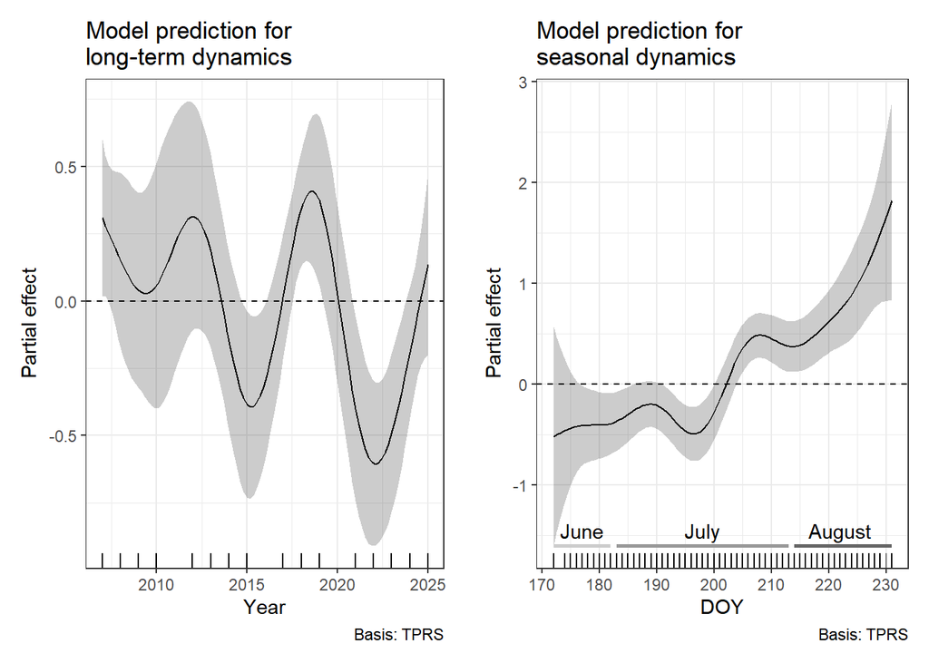

На этих рисунках, как и везде, горизонтальная пунктирная линия отражает среднее по популяции значение. Ниже нуля - меньше среднего и наоборот.

+++++++++++++++++++++

Нужны средние по доле особей с пустыми желудками по отдельным годам для конкретики. Из рисунков, приведенных выше, этих данных не видно.

| Year | Prop_empty |
| --- | --- |
| 2007 | 36.40 |
| 2008 | 20.00 |
| 2009 | 26.26 |
| 2010 | 23.08 |
| 2012 | 19.61 |
| 2013 | 33.82 |
| 2014 | 28.17 |
| 2015 | 12.70 |
| 2017 | 22.07 |
| 2018 | 33.61 |
| 2019 | 28.41 |
| 2021 | 17.97 |
| 2022 | 32.10 |
| 2023 | 14.63 |
| 2024 | 22.32 |
| 2025 | 29.56 |

## Динамика веса пищевого комка в заполненных желудках

Анализируем общий вес пищи в желудках

Модель, котрую строим имеет следующий вид

Total_Weight ~ s(Year) + s(DOY) + s(L)

Вот результаты подбора модели

```
##
## Family: gaussian
## Link function: identity
##
## Formula:
## Total_Weight ~ s(Year) + s(DOY) + s(L, k = 5)
##
## Parametric coefficients:
##             Estimate Std. Error t value Pr(>|t|)
## (Intercept)   8.6887     0.2271   38.26   <2e-16 ***
## ---
## Signif. codes:  0 '***' 0.001 '**' 0.01 '*' 0.05 '.' 0.1 ' ' 1
##
## Approximate significance of smooth terms:
##           edf Ref.df      F p-value
## s(Year) 6.839  7.877  4.588 1.5e-05 ***
## s(DOY)  1.867  2.366  1.237   0.333
## s(L)    3.662  3.934 37.909 < 2e-16 ***
## ---
## Signif. codes:  0 '***' 0.001 '**' 0.01 '*' 0.05 '.' 0.1 ' ' 1
##
## R-sq.(adj) =  0.106   Deviance explained = 11.3%
## GCV = 81.365  Scale est. = 80.669    n = 1564
```

At! Данные за 2016 убрал.

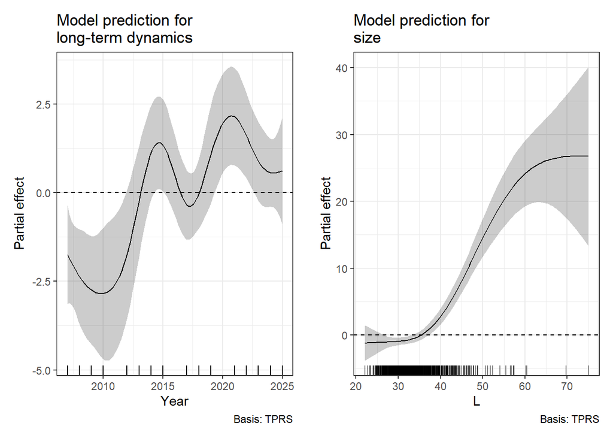

## Состав пищевого комка

## Динамика встречаемости пищевых объектов

Ранжируем виды по их встречаемости (за все годы исследования)

```
## [1] "G.aculeatus"          "Nereis_spp."          "Fish_eggs"
## [4] "C.pallasii_marisalbi" "O.aculeata"
```

Для этих видов будем строить модель многолетней и сезонной динамики встречаемости.

Модель имеет следующий вид

Presence ~ s(Year, by = Species) + s(DOY, by = Species) + s(L, by = Species, k =5) + Species

То есть мы сразу очениваем и многолетнюю динамику, и сезонную динамику и связь с размерами.

Вот результаты этой модели

```
##
## Family: binomial
## Link function: logit
##
## Formula:
## Presence ~ s(Year, by = Species, k = 5) + s(DOY, by = Species,
##     k = 5) + s(L, by = Species, k = 5) + Species
##
## Parametric coefficients:
##                             Estimate Std. Error z value Pr(>|z|)
## (Intercept)                 -0.21383    0.05600  -3.818 0.000134 ***
## SpeciesC.pallasii_marisalbi -2.69269    0.13831 -19.468  < 2e-16 ***
## SpeciesFish_eggs            -1.82159    0.11468 -15.884  < 2e-16 ***
## SpeciesO.aculeata           -2.51445    0.12297 -20.447  < 2e-16 ***
## SpeciesNereis_spp.          -1.39877    0.09545 -14.655  < 2e-16 ***
## ---
## Signif. codes:  0 '***' 0.001 '**' 0.01 '*' 0.05 '.' 0.1 ' ' 1
##
## Approximate significance of smooth terms:
##                                       edf Ref.df Chi.sq  p-value
## s(Year):SpeciesG.aculeatus          1.952  2.354  8.697 0.017556 *
## s(Year):SpeciesC.pallasii_marisalbi 3.956  3.999 41.817  < 2e-16 ***
## s(Year):SpeciesFish_eggs            1.000  1.001  4.285 0.038529 *
## s(Year):SpeciesO.aculeata           1.000  1.001  0.439 0.507895
## s(Year):SpeciesNereis_spp.          3.946  3.998 78.940  < 2e-16 ***
## s(DOY):SpeciesG.aculeatus           3.148  3.593 99.260  < 2e-16 ***
## s(DOY):SpeciesC.pallasii_marisalbi  2.917  3.442 18.687 0.000539 ***
## s(DOY):SpeciesFish_eggs             3.226  3.649 71.238  < 2e-16 ***
## s(DOY):SpeciesO.aculeata            3.376  3.788 14.608 0.003601 **
## s(DOY):SpeciesNereis_spp.           3.951  3.998 82.526  < 2e-16 ***
## s(L):SpeciesG.aculeatus             3.348  3.774 68.306  < 2e-16 ***
## s(L):SpeciesC.pallasii_marisalbi    1.000  1.001  7.846 0.005103 **
## s(L):SpeciesFish_eggs               3.421  3.820 56.745  < 2e-16 ***
## s(L):SpeciesO.aculeata              1.001  1.001  4.029 0.044772 *
## s(L):SpeciesNereis_spp.             1.000  1.001 10.223 0.001390 **
## ---
## Signif. codes:  0 '***' 0.001 '**' 0.01 '*' 0.05 '.' 0.1 ' ' 1
##
## R-sq.(adj) =  0.222   Deviance explained = 21.9%
## UBRE = -0.22123  Scale est. = 1         n = 7820
```

Не выявлена многолетняя динамика только у O.aculeata (!!! Отличается от предыдущего результата, когда 2016 использовал).

Связь с размерами есть у всех (!!! Отличается от предыдущего результата).

**Встречаемость видов в зависимости от размеров трески**

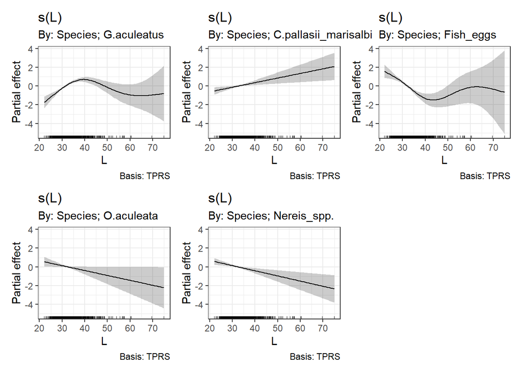

**Сезонная динамика встречаемости видов**

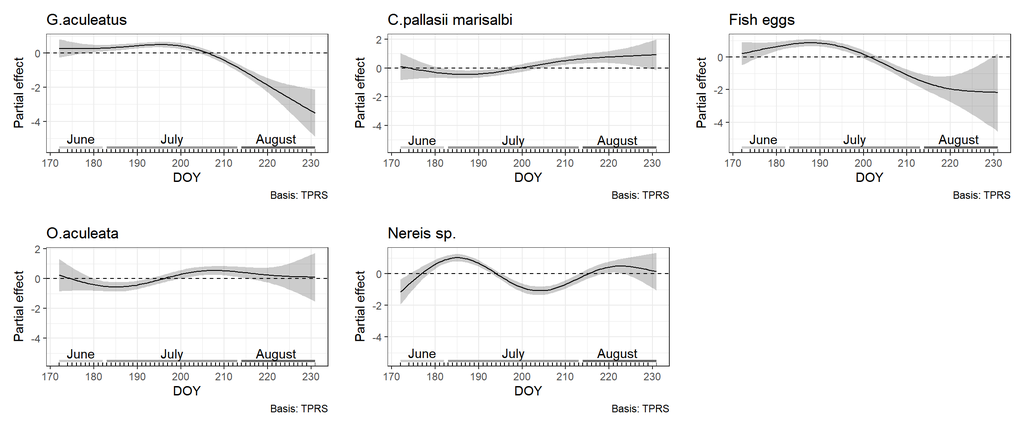

Первую половину лета треска ест колюшку и икру, вторую половину лета - селедку и, возможно, офиур. С нереисами сложнее. Первый пик - это явно период хода нереиса в первой половине лета. Второй пик - может это другой вид нереиса? Надо поискать данные по периодам хода у pelgica и virens.

**Многолетняя динамика встречаемости видов**

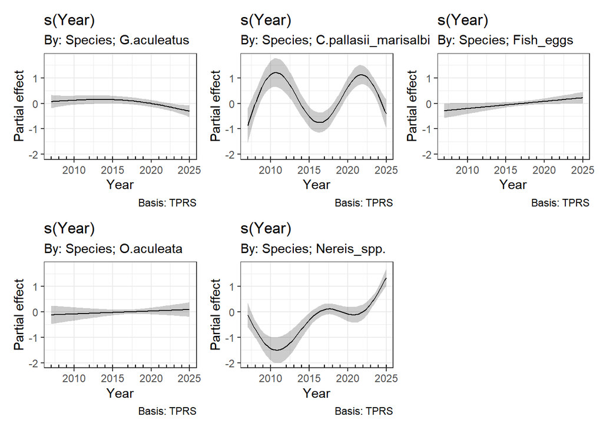

## Динамика доли пищевых объектов

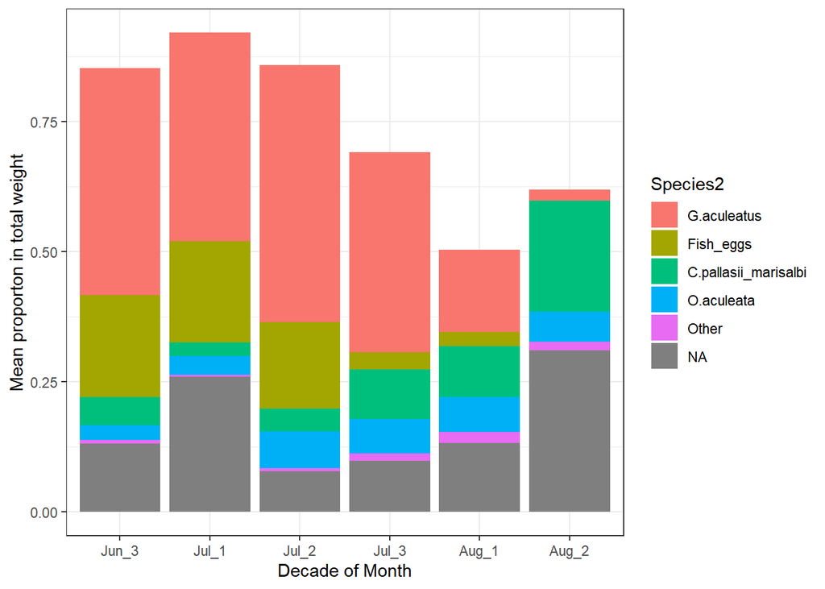

# Новый кусок

## Другой способ вычисления доли

За 100% берется вся сумма весов жертв за декаду. Далее на графике отражаем долю суммы каждого вида в общей сумме за декаду.

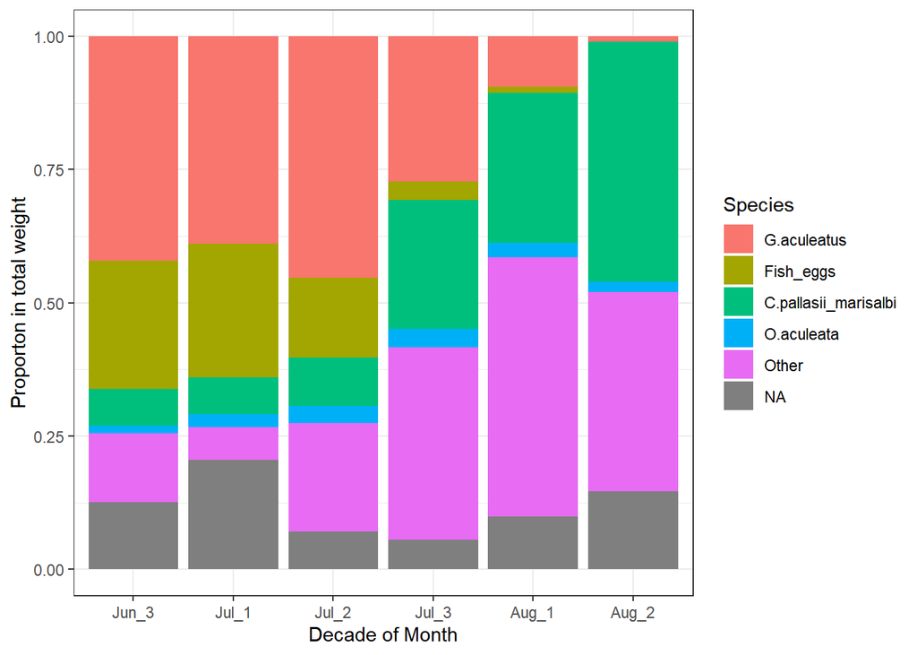

Это другой способ визуализации предыдущего графика. Этот вариант мне кажется лучше. В принципе, можно пустить его в параллель с визуализацией сезонной динамики встречаемости видов (общий ход сезонной динамики встречаемости и доли в пищевом комке похожи)

[figure not shown]

## Многолетняя динамика доли

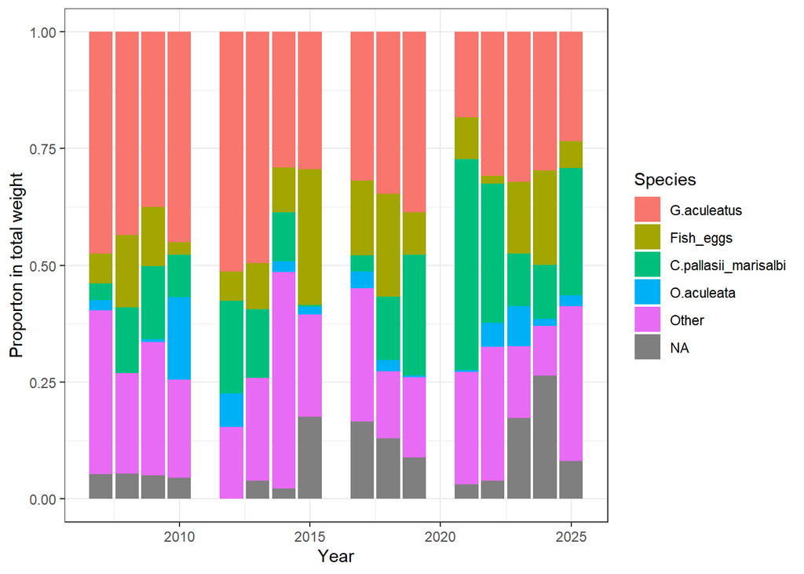

Другой вариант визуализации этого же графика. Здесь точки - исходные доли, синие линии - сглаженная тенденция.

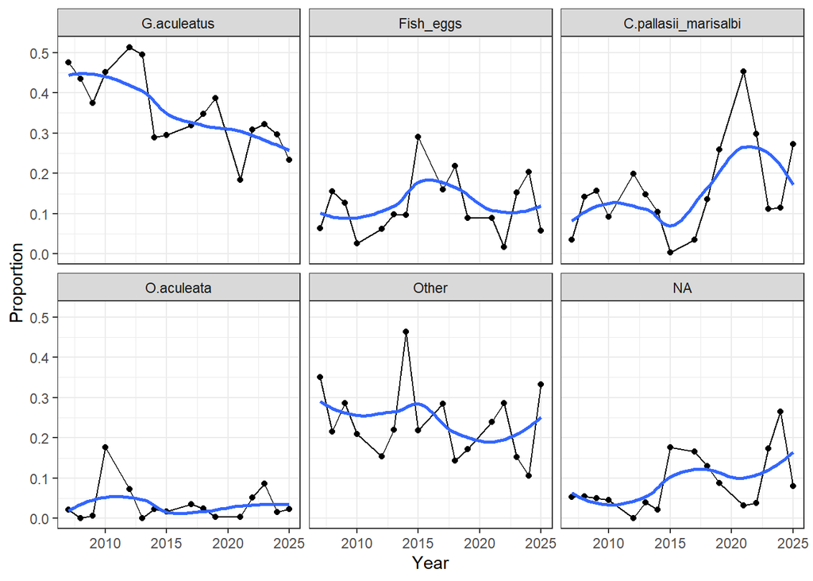